# **Facial Emotion Detection**

## **Problem Definition**

**The context:** Why is this problem important to solve?  
**The objectives:** What is the intended goal?  
**The key questions:** What are the key questions that need to be answered?  
**The problem formulation:** What are we trying to solve using data science?

## **About the dataset**

The data set consists of 3 folders, i.e., 'test', 'train', and 'validation'. Each of these folders has four subfolders:

**‘happy’**: Images of people who have happy facial expressions.  
**‘sad’**: Images of people with sad or upset facial expressions.  
**‘surprise’**: Images of people who have shocked or surprised facial expressions.  
**‘neutral’**: Images of people showing no prominent emotion in their facial expression at all.

## **Mounting the Drive**

**NOTE:** Please use Google Colab from your browser for this notebook. **Google.colab is NOT a library that can be downloaded locally on your device.**

```python
from google.colab import drive

# Mount Google Drive
drive.mount('/content/drive')
```

**Importing the Libraries**

```python
import numpy as np
import pandas as pd
import matplotlib.pyplot as plt
import seaborn as sns
from sklearn.model_selection import train_test_split
from sklearn.preprocessing import LabelEncoder
from sklearn.metrics import classification_report, confusion_matrix
from tensorflow.keras.preprocessing.image import ImageDataGenerator
from tensorflow.keras.models import Sequential
from tensorflow.keras.layers import Conv2D, MaxPooling2D, Flatten, Dense, Dropout
from tensorflow.keras.optimizers import Adam
```

### **Let us load and unzip the data**

**Note:**

- You must download the dataset from the link provided on Olympus and upload the same on your Google drive before executing the code in the next cell.
- In case of any error, please make sure that the path of the file is correct as the path may be different for you.

```python
import os
from zipfile import ZipFile

# Define the path to the zip file
zip_file_path = '/content/drive/MyDrive/data/Facial_emotion_images.zip'
```

```python
# Define the directory to extract the data
extracted_dir_path = '/content/drive/MyDrive/data/Facial_emotion_images'
```

```python
# Check if the extraction directory exists, if not, create it
if not os.path.exists(extracted_dir_path):
    os.makedirs(extracted_dir_path)
```

```python
# Unzip the file
with ZipFile(zip_file_path, 'r') as zip_ref:
    zip_ref.extractall(extracted_dir_path)
```

```python
# List the extracted files and directories
extracted_files = os.listdir(extracted_dir_path)
print("Extracted files and directories:")
print(extracted_files)
```

```
Extracted files and directories:
['Facial_emotion_images']
```

## **Visualizing our Classes**

Let's look at our classes.

**Write down your observation for each class. What do you think can be a unique feature of each emotion, that separates it from the remaining classes?**

### **Happy**

**Observations and Insights:__**

Observation: Faces with smiling expressions, raised cheeks, and possibly squinted eyes. Potential unique feature: Broad smiles with visible teeth and raised cheekbones could be distinguishing features. Additionally, the presence of crow's feet around the eyes due to smiling might be characteristic.

### **Sad**

**Observations and Insights:__**

Observation: Faces with downturned corners of the mouth, droopy eyelids, and possibly furrowed brows. Potential unique feature: Downturned corners of the mouth along with droopy eyelids and eyebrows could be distinguishing features. Tear-filled or watery eyes might also be indicative of sadness.

### **Neutral**

**Observations and Insights:__**

Observation: Faces with relaxed expressions, neither smiling nor frowning, with eyes and mouth closed or partially open. Potential unique feature: A lack of pronounced facial expressions, with a neutral mouth and eyes, could be distinguishing. The absence of wrinkles or tension in facial muscles might also be characteristic.

### **Surprised**

**Observations and Insights:__**

Observation: Faces with widened eyes, raised eyebrows, and possibly open mouths. Potential unique feature: Widened eyes and raised eyebrows accompanied by an open mouth could be distinguishing features. The presence of wrinkles on the forehead due to raised eyebrows might also be characteristic.

## **Checking Distribution of Classes**

```python
# Define the paths to the train, validation, and test directories
train_dir = '/content/drive/MyDrive/data/Facial_emotion_images/Facial_emotion_images/train'
validation_dir = '/content/drive/MyDrive/data/Facial_emotion_images/Facial_emotion_images/validation'
test_dir = '/content/drive/MyDrive/data/Facial_emotion_images/Facial_emotion_images/test'

# Function to count the number of images in each class
def count_images(directory):
    classes = os.listdir(directory)
    class_counts = {}
    for class_name in classes:
        class_path = os.path.join(directory, class_name)
        num_images = len(os.listdir(class_path))
        class_counts[class_name] = num_images
    return class_counts

# Count images in train directory
train_class_counts = count_images(train_dir)
print("Train class counts:")
print(train_class_counts)

# Count images in validation directory
validation_class_counts = count_images(validation_dir)
print("\nValidation class counts:")
print(validation_class_counts)

# Count images in test directory
test_class_counts = count_images(test_dir)
print("\nTest class counts:")
print(test_class_counts)
```

```
Train class counts:
{'neutral': 3978, 'happy': 3976, 'sad': 3982, 'surprise': 3173}

Validation class counts:
{'happy': 1825, 'neutral': 1216, 'sad': 1139, 'surprise': 797}

Test class counts:
{'happy': 32, 'neutral': 32, 'sad': 32, 'surprise': 32}
```

**Observations and Insights:__**

**Think About It:**

- Are the classes equally distributed? If not, do you think the imbalance is too high? Will it be a problem as we progress?
- Are there any Exploratory Data Analysis tasks that we can do here? Would they provide any meaningful insights?

The training set is fairly balanced, save for the 'surprise' class which has a slightly lower count of images.

In the validation set there is an imbalance regarding the classes to some degree, considering the 'happy' class having the highest count while the 'surprise' class again has the lowest count.

The test set appears to be too small in size with only 32 images per class, roviding an insufficient amounnt of training data to provide a robust evaluation.

Based on the above observations, it is vital to consider strategies to handle class imbalance such as data augmentation or adjusting class weights during the training process

## **Creating our Data Loaders**

In this section, we are creating data loaders that we will use as inputs to our Neural Network.

**You have two options for the color_mode. You can set it to color_mode = 'rgb' or color_mode = 'grayscale'. You will need to try out both and see for yourself which one gives better performance.**

```python
# Define data generators for training, validation, and test sets
train_datagen = ImageDataGenerator(rescale=1./255)
validation_datagen = ImageDataGenerator(rescale=1./255)
test_datagen = ImageDataGenerator(rescale=1./255)

# Set the desired color mode ('rgb' or 'grayscale')
color_mode = 'rgb'

# Define batch size
batch_size = 32

# Define target image size
target_size = (150, 150)

# Define class mode
class_mode = 'categorical'  # Assuming multi-class classification

# Define training data loader
train_generator = train_datagen.flow_from_directory(
    train_dir,
    target_size=target_size,
    batch_size=batch_size,
    color_mode=color_mode,
    class_mode=class_mode
)

# Define validation data loader
validation_generator = validation_datagen.flow_from_directory(
    validation_dir,
    target_size=target_size,
    batch_size=batch_size,
    color_mode=color_mode,
    class_mode=class_mode
)

# Define test data loader
test_generator = test_datagen.flow_from_directory(
    test_dir,
    target_size=target_size,
    batch_size=batch_size,
    color_mode=color_mode,
    class_mode=class_mode
)
```

```
Found 15109 images belonging to 4 classes.
Found 4977 images belonging to 4 classes.
Found 128 images belonging to 4 classes.
```

## **Model Building**

**Think About It:**

- Are Convolutional Neural Networks the right approach? Should we have gone with Artificial Neural Networks instead?
- What are the advantages of CNNs over ANNs and are they applicable here?

CNNs are preferred over traditional ANNs for facial emotion detection from images due to the following reasons: Spatial Hierarchical Features: CNNs excel at capturing spatial hierarchies of features crucial for recognizing patterns in images.

Translation Invariance: They are inherently translation invariant, making them robust to transformations like translations and rotations.

Local Receptive Fields: CNNs use local receptive fields to capture local patterns, such as edges and textures, at different spatial scales.

Parameter Sharing: They exploit spatial correlation by sharing parameters across the input, making them efficient in terms of memory and computational cost.

Adaptability to Image Data: CNN architectures can handle varying image sizes and resolutions, making them versatile for image-related tasks.

### **Creating the Base Neural Network**

```python
from tensorflow.keras.models import Sequential
from tensorflow.keras.layers import Conv2D, MaxPooling2D, Flatten, Dense, Dropout

# Define the CNN model
model = Sequential()

# Convolutional layers
model.add(Conv2D(32, (3, 3), activation='relu', input_shape=(150, 150, 3)))
model.add(MaxPooling2D((2, 2)))
model.add(Conv2D(64, (3, 3), activation='relu'))
model.add(MaxPooling2D((2, 2)))
model.add(Conv2D(128, (3, 3), activation='relu'))
model.add(MaxPooling2D((2, 2)))

# Flatten layer
model.add(Flatten())

# Dense layers
model.add(Dense(128, activation='relu'))
model.add(Dropout(0.5))
model.add(Dense(4, activation='softmax'))  # Assuming 4 classes for happy, sad, surprise, neutral

# Compile the model
model.compile(optimizer='adam',
              loss='categorical_crossentropy',
              metrics=['accuracy'])

# Print model summary
model.summary()
```

```
Model: "sequential"
_________________________________________________________________
 Layer (type)                Output Shape              Param #
=================================================================
 conv2d (Conv2D)             (None, 148, 148, 32)      896

 max_pooling2d (MaxPooling2  (None, 74, 74, 32)        0
 D)

 conv2d_1 (Conv2D)           (None, 72, 72, 64)        18496

 max_pooling2d_1 (MaxPoolin  (None, 36, 36, 64)        0
 g2D)

 conv2d_2 (Conv2D)           (None, 34, 34, 128)       73856

 max_pooling2d_2 (MaxPoolin  (None, 17, 17, 128)       0
 g2D)

 flatten (Flatten)           (None, 36992)             0

 dense (Dense)               (None, 128)               4735104

 dropout (Dropout)           (None, 128)               0

 dense_1 (Dense)             (None, 4)                 516

=================================================================
Total params: 4828868 (18.42 MB)
Trainable params: 4828868 (18.42 MB)
Non-trainable params: 0 (0.00 Byte)
_________________________________________________________________
```

### **Compiling and Training the Model**

```python
# Compile the model
model.compile(optimizer='adam',
              loss='categorical_crossentropy',
              metrics=['accuracy'])

# Define number of epochs
epochs = 10

# Train the model
history = model.fit(
    train_generator,
    steps_per_epoch=train_generator.samples // batch_size,
    epochs=epochs,
    validation_data=validation_generator,
    validation_steps=validation_generator.samples // batch_size
)
```

### **Evaluating the Model on the Test Set**

```python
# Evaluate the model on the test set
test_loss, test_accuracy = model.evaluate(test_generator)

# Print the test loss and accuracy
print("Test Loss:", test_loss)
print("Test Accuracy:", test_accuracy)
```

```
Test Loss: 1.1427788734436035
Test Accuracy: 0.6875
```

**Observations and Insights:__**

### **Creating the second Convolutional Neural Network**

- Try out a slightly larger architecture

```python
from tensorflow.keras.models import Sequential
from tensorflow.keras.layers import Conv2D, MaxPooling2D, Flatten, Dense, Dropout

# Define the CNN model
model_large = Sequential()

# Convolutional layers
model_large.add(Conv2D(32, (3, 3), activation='relu', input_shape=(150, 150, 3)))
model_large.add(MaxPooling2D((2, 2)))
model_large.add(Conv2D(64, (3, 3), activation='relu'))
model_large.add(MaxPooling2D((2, 2)))
model_large.add(Conv2D(128, (3, 3), activation='relu'))
model_large.add(MaxPooling2D((2, 2)))
model_large.add(Conv2D(256, (3, 3), activation='relu'))
model_large.add(MaxPooling2D((2, 2)))

# Flatten layer
model_large.add(Flatten())

# Dense layers
model_large.add(Dense(256, activation='relu'))
model_large.add(Dropout(0.5))
model_large.add(Dense(128, activation='relu'))
model_large.add(Dropout(0.5))
model_large.add(Dense(4, activation='softmax'))  # Assuming 4 classes for happy, sad, surprise, neutral

# Compile the model
model_large.compile(optimizer='adam',
                    loss='categorical_crossentropy',
                    metrics=['accuracy'])

# Print model summary
model_large.summary()
```

```
Model: "sequential_1"
_________________________________________________________________
 Layer (type)                Output Shape              Param #
=================================================================
 conv2d_3 (Conv2D)           (None, 148, 148, 32)      896

 max_pooling2d_3 (MaxPoolin  (None, 74, 74, 32)        0
 g2D)

 conv2d_4 (Conv2D)           (None, 72, 72, 64)        18496

 max_pooling2d_4 (MaxPoolin  (None, 36, 36, 64)        0
 g2D)

 conv2d_5 (Conv2D)           (None, 34, 34, 128)       73856

 max_pooling2d_5 (MaxPoolin  (None, 17, 17, 128)       0
 g2D)

 conv2d_6 (Conv2D)           (None, 15, 15, 256)       295168

 max_pooling2d_6 (MaxPoolin  (None, 7, 7, 256)         0
 g2D)

 flatten_1 (Flatten)         (None, 12544)             0

 dense_2 (Dense)             (None, 256)               3211520

 dropout_1 (Dropout)         (None, 256)               0

 dense_3 (Dense)             (None, 128)               32896

 dropout_2 (Dropout)         (None, 128)               0

 dense_4 (Dense)             (None, 4)                 516

=================================================================
Total params: 3633348 (13.86 MB)
Trainable params: 3633348 (13.86 MB)
Non-trainable params: 0 (0.00 Byte)
_________________________________________________________________
```

### **Compiling and Training the Model**

```python
# Compile the larger model
model_large.compile(optimizer='adam',
                    loss='categorical_crossentropy',
                    metrics=['accuracy'])

# Define number of epochs
epochs = 10

# Train the larger model
history_large = model_large.fit(
    train_generator,
    steps_per_epoch=train_generator.samples // batch_size,
    epochs=epochs,
    validation_data=validation_generator,
    validation_steps=validation_generator.samples // batch_size
)
```

### **Evaluating the Model on the Test Set**

```python
# Evaluate the larger model on the test set
test_loss_large, test_accuracy_large = model_large.evaluate(test_generator)

# Print the test loss and accuracy for the larger model
print("Test Loss (Larger Model):", test_loss_large)
print("Test Accuracy (Larger Model):", test_accuracy_large)
```

```
Test Loss (Larger Model): 0.701310396194458
Test Accuracy (Larger Model): 0.734375
```

**Observations and Insights:__**

## **Think About It:**

- Did the models have a satisfactory performance? If not, then what are the possible reasons?
- Which Color mode showed better overall performance? What are the possible reasons? Do you think having 'rgb' color mode is needed because the images are already black and white?

## **Transfer Learning Architectures**

### **Creating our Data Loaders for Transfer Learning Architectures**

In this section, we are creating data loaders that we will use as inputs to our Neural Network. We will have to go with color_mode = 'rgb' as this is the required format for the transfer learning architectures.

```python
from tensorflow.keras.preprocessing.image import ImageDataGenerator

# Define batch size
batch_size = 32

# Define target image size
target_size = (150, 150)

# Define class mode
class_mode = 'categorical'  # Assuming multi-class classification

# Set the desired color mode to 'rgb'
color_mode_rgb = 'rgb'

# Define data generators for training, validation, and test sets
train_datagen_rgb = ImageDataGenerator(rescale=1./255)
validation_datagen_rgb = ImageDataGenerator(rescale=1./255)
test_datagen_rgb = ImageDataGenerator(rescale=1./255)

# Define training data loader for RGB images
train_generator_rgb = train_datagen_rgb.flow_from_directory(
    train_dir,
    target_size=target_size,
    batch_size=batch_size,
    color_mode=color_mode_rgb,
    class_mode=class_mode
)

# Define validation data loader for RGB images
validation_generator_rgb = validation_datagen_rgb.flow_from_directory(
    validation_dir,
    target_size=target_size,
    batch_size=batch_size,
    color_mode=color_mode_rgb,
    class_mode=class_mode
)

# Define test data loader for RGB images
test_generator_rgb = test_datagen_rgb.flow_from_directory(
    test_dir,
    target_size=target_size,
    batch_size=batch_size,
    color_mode=color_mode_rgb,
    class_mode=class_mode
)
```

```
Found 15109 images belonging to 4 classes.
Found 4977 images belonging to 4 classes.
Found 128 images belonging to 4 classes.
```

## **VGG16 Model**

### **Importing the VGG16 Architecture**

```python
from tensorflow.keras.applications import VGG16

# Load the VGG16 model with pre-trained weights on ImageNet
vgg16_model = VGG16(weights='imagenet', include_top=False, input_shape=(150, 150, 3))

# Freeze the pre-trained layers
for layer in vgg16_model.layers:
    layer.trainable = False

# Print model summary
vgg16_model.summary()
```

```
Downloading data from https://storage.googleapis.com/tensorflow/keras-applications/vgg16/vgg16_weights_tf_dim_ordering_tf_kernels_notop.h5
Model: "vgg16"
_________________________________________________________________
 Layer (type)                Output Shape              Param #
=================================================================
 input_1 (InputLayer)        [(None, 150, 150, 3)]     0

 block1_conv1 (Conv2D)       (None, 150, 150, 64)      1792

 block1_conv2 (Conv2D)       (None, 150, 150, 64)      36928

 block1_pool (MaxPooling2D)  (None, 75, 75, 64)        0

 block2_conv1 (Conv2D)       (None, 75, 75, 128)       73856

 block2_conv2 (Conv2D)       (None, 75, 75, 128)       147584

 block2_pool (MaxPooling2D)  (None, 37, 37, 128)       0

 block3_conv1 (Conv2D)       (None, 37, 37, 256)       295168

 block3_conv2 (Conv2D)       (None, 37, 37, 256)       590080

 block3_conv3 (Conv2D)       (None, 37, 37, 256)       590080

 block3_pool (MaxPooling2D)  (None, 18, 18, 256)       0

 block4_conv1 (Conv2D)       (None, 18, 18, 512)       1180160

 block4_conv2 (Conv2D)       (None, 18, 18, 512)       2359808

 block4_conv3 (Conv2D)       (None, 18, 18, 512)       2359808

 block4_pool (MaxPooling2D)  (None, 9, 9, 512)         0

 block5_conv1 (Conv2D)       (None, 9, 9, 512)         2359808

 block5_conv2 (Conv2D)       (None, 9, 9, 512)         2359808

 block5_conv3 (Conv2D)       (None, 9, 9, 512)         2359808

 block5_pool (MaxPooling2D)  (None, 4, 4, 512)         0

=================================================================
Total params: 14714688 (56.13 MB)
Trainable params: 0 (0.00 Byte)
Non-trainable params: 14714688 (56.13 MB)
_________________________________________________________________
```

### **Model Building**

- Import VGG16 upto the layer of your choice and add Fully Connected layers on top of it.

```python
from tensorflow.keras.applications import VGG16
from tensorflow.keras.models import Model
from tensorflow.keras.layers import Flatten, Dense, Dropout

# Load the VGG16 model with pre-trained weights up to a specific layer
vgg16_base = VGG16(weights='imagenet', include_top=False, input_shape=(150, 150, 3))

# Freeze the layers of the VGG16 base
for layer in vgg16_base.layers:
    layer.trainable = False

# Add custom fully connected layers on top of the VGG16 base
x = Flatten()(vgg16_base.output)
x = Dense(256, activation='relu')(x)
x = Dropout(0.5)(x)
x = Dense(128, activation='relu')(x)
output = Dense(4, activation='softmax')(x)  # Assuming 4 classes for happy, sad, surprise, neutral

# Create the final model
model_vgg16 = Model(inputs=vgg16_base.input, outputs=output)

# Compile the model
model_vgg16.compile(optimizer='adam',
                    loss='categorical_crossentropy',
                    metrics=['accuracy'])

# Print model summary
model_vgg16.summary()
```

```
Model: "model"
_________________________________________________________________
 Layer (type)                Output Shape              Param #
=================================================================
 input_2 (InputLayer)        [(None, 150, 150, 3)]     0

 block1_conv1 (Conv2D)       (None, 150, 150, 64)      1792

 block1_conv2 (Conv2D)       (None, 150, 150, 64)      36928

 block1_pool (MaxPooling2D)  (None, 75, 75, 64)        0

 block2_conv1 (Conv2D)       (None, 75, 75, 128)       73856

 block2_conv2 (Conv2D)       (None, 75, 75, 128)       147584

 block2_pool (MaxPooling2D)  (None, 37, 37, 128)       0

 block3_conv1 (Conv2D)       (None, 37, 37, 256)       295168

 block3_conv2 (Conv2D)       (None, 37, 37, 256)       590080

 block3_conv3 (Conv2D)       (None, 37, 37, 256)       590080

 block3_pool (MaxPooling2D)  (None, 18, 18, 256)       0

 block4_conv1 (Conv2D)       (None, 18, 18, 512)       1180160

 block4_conv2 (Conv2D)       (None, 18, 18, 512)       2359808

 block4_conv3 (Conv2D)       (None, 18, 18, 512)       2359808

 block4_pool (MaxPooling2D)  (None, 9, 9, 512)         0

 block5_conv1 (Conv2D)       (None, 9, 9, 512)         2359808

 block5_conv2 (Conv2D)       (None, 9, 9, 512)         2359808

 block5_conv3 (Conv2D)       (None, 9, 9, 512)         2359808

 block5_pool (MaxPooling2D)  (None, 4, 4, 512)         0

 flatten_2 (Flatten)         (None, 8192)              0

 dense_5 (Dense)             (None, 256)               2097408

 dropout_3 (Dropout)         (None, 256)               0

 dense_6 (Dense)             (None, 128)               32896

 dense_7 (Dense)             (None, 4)                 516

=================================================================
Total params: 16845508 (64.26 MB)
Trainable params: 2130820 (8.13 MB)
Non-trainable params: 14714688 (56.13 MB)
_________________________________________________________________
```

### **Compiling and Training the VGG16 Model**

```python
# Compile the VGG16-based model
model_vgg16.compile(optimizer='adam',
                     loss='categorical_crossentropy',
                     metrics=['accuracy'])

# Define the number of epochs
epochs = 10

# Train the VGG16-based model
history_vgg16 = model_vgg16.fit(
    train_generator_rgb,
    steps_per_epoch=train_generator_rgb.samples // batch_size,
    epochs=epochs,
    validation_data=validation_generator_rgb,
    validation_steps=validation_generator_rgb.samples // batch_size
)
```

### **Evaluating the VGG16 model**

```python
# Evaluate the VGG16-based model on the test set
test_loss_vgg16, test_accuracy_vgg16 = model_vgg16.evaluate(test_generator_rgb)

# Print the test loss and accuracy for the VGG16-based model
print("Test Loss (VGG16 Model):", test_loss_vgg16)
print("Test Accuracy (VGG16 Model):", test_accuracy_vgg16)
```

```
Test Loss (VGG16 Model): 0.78746497631073
Test Accuracy (VGG16 Model): 0.671875
```

**Think About It:**

- What do you infer from the general trend in the training performance?
- Is the training accuracy consistently improving?
- Is the validation accuracy also improving similarly?

**Observations and Insights:__**

**Note: You can even go back and build your own architecture on top of the VGG16 Transfer layer and see if you can improve the performance**

## **ResNet V2 Model**

```python
from tensorflow.keras.applications import ResNet50V2

# Load the ResNet V2 model with pre-trained weights on ImageNet
resnet_v2_model = ResNet50V2(weights='imagenet', include_top=False, input_shape=(150, 150, 3))

# Freeze the pre-trained layers
for layer in resnet_v2_model.layers:
    layer.trainable = False

# Print model summary
resnet_v2_model.summary()
```

```
Downloading data from https://storage.googleapis.com/tensorflow/keras-applications/resnet/resnet50v2_weights_tf_dim_ordering_tf_kernels_notop.h5
Model: "resnet50v2"
__________________________________________________________________________________________________
 Layer (type)                Output Shape                 Param #   Connected to
==================================================================================================
 input_3 (InputLayer)        [(None, 150, 150, 3)]        0         []

 conv1_pad (ZeroPadding2D)   (None, 156, 156, 3)          0         ['input_3[0][0]']

 conv1_conv (Conv2D)         (None, 75, 75, 64)           9472      ['conv1_pad[0][0]']

 pool1_pad (ZeroPadding2D)   (None, 77, 77, 64)           0         ['conv1_conv[0][0]']

 pool1_pool (MaxPooling2D)   (None, 38, 38, 64)           0         ['pool1_pad[0][0]']

 conv2_block1_preact_bn (Ba  (None, 38, 38, 64)           256       ['pool1_pool[0][0]']
 tchNormalization)

 conv2_block1_preact_relu (  (None, 38, 38, 64)           0         ['conv2_block1_preact_bn[0][0]
 Activation)                                                        ']

 conv2_block1_1_conv (Conv2  (None, 38, 38, 64)           4096      ['conv2_block1_preact_relu[0][
 D)                                                                 0]']

 conv2_block1_1_bn (BatchNo  (None, 38, 38, 64)           256       ['conv2_block1_1_conv[0][0]']
 rmalization)

 conv2_block1_1_relu (Activ  (None, 38, 38, 64)           0         ['conv2_block1_1_bn[0][0]']
 ation)

 conv2_block1_2_pad (ZeroPa  (None, 40, 40, 64)           0         ['conv2_block1_1_relu[0][0]']
 dding2D)

 conv2_block1_2_conv (Conv2  (None, 38, 38, 64)           36864     ['conv2_block1_2_pad[0][0]']
 D)

 conv2_block1_2_bn (BatchNo  (None, 38, 38, 64)           256       ['conv2_block1_2_conv[0][0]']
 rmalization)

 conv2_block1_2_relu (Activ  (None, 38, 38, 64)           0         ['conv2_block1_2_bn[0][0]']
```

[output cut: 519 more lines]

```
 D)

 conv5_block3_out (Add)      (None, 5, 5, 2048)           0         ['conv5_block2_out[0][0]',
                                                                     'conv5_block3_3_conv[0][0]']

 post_bn (BatchNormalizatio  (None, 5, 5, 2048)           8192      ['conv5_block3_out[0][0]']
 n)

 post_relu (Activation)      (None, 5, 5, 2048)           0         ['post_bn[0][0]']

==================================================================================================
Total params: 23564800 (89.89 MB)
Trainable params: 0 (0.00 Byte)
Non-trainable params: 23564800 (89.89 MB)
__________________________________________________________________________________________________
```

### **Model Building**

- Import Resnet v2 upto the layer of your choice and add Fully Connected layers on top of it.

```python
from tensorflow.keras.applications import ResNet50V2
from tensorflow.keras.models import Model
from tensorflow.keras.layers import Flatten, Dense, Dropout

# Load the ResNet V2 model with pre-trained weights up to a specific layer
resnet_v2_base = ResNet50V2(weights='imagenet', include_top=False, input_shape=(150, 150, 3))

# Freeze the layers of the ResNet V2 base
for layer in resnet_v2_base.layers:
    layer.trainable = False

# Add custom fully connected layers on top of the ResNet V2 base
x = Flatten()(resnet_v2_base.output)
x = Dense(256, activation='relu')(x)
x = Dropout(0.5)(x)
x = Dense(128, activation='relu')(x)
output = Dense(4, activation='softmax')(x)  # Assuming 4 classes for happy, sad, surprise, neutral

# Create the final model
model_resnet_v2 = Model(inputs=resnet_v2_base.input, outputs=output)

# Compile the model
model_resnet_v2.compile(optimizer='adam',
                        loss='categorical_crossentropy',
                        metrics=['accuracy'])

# Print model summary
model_resnet_v2.summary()
```

[output not shown]

```
Model: "model_1"
__________________________________________________________________________________________________
 Layer (type)                Output Shape                 Param #   Connected to
==================================================================================================
 input_4 (InputLayer)        [(None, 150, 150, 3)]        0         []

 conv1_pad (ZeroPadding2D)   (None, 156, 156, 3)          0         ['input_4[0][0]']

 conv1_conv (Conv2D)         (None, 75, 75, 64)           9472      ['conv1_pad[0][0]']

 pool1_pad (ZeroPadding2D)   (None, 77, 77, 64)           0         ['conv1_conv[0][0]']

 pool1_pool (MaxPooling2D)   (None, 38, 38, 64)           0         ['pool1_pad[0][0]']

 conv2_block1_preact_bn (Ba  (None, 38, 38, 64)           256       ['pool1_pool[0][0]']
 tchNormalization)

 conv2_block1_preact_relu (  (None, 38, 38, 64)           0         ['conv2_block1_preact_bn[0][0]
 Activation)                                                        ']

 conv2_block1_1_conv (Conv2  (None, 38, 38, 64)           4096      ['conv2_block1_preact_relu[0][
 D)                                                                 0]']

 conv2_block1_1_bn (BatchNo  (None, 38, 38, 64)           256       ['conv2_block1_1_conv[0][0]']
 rmalization)

 conv2_block1_1_relu (Activ  (None, 38, 38, 64)           0         ['conv2_block1_1_bn[0][0]']
 ation)

 conv2_block1_2_pad (ZeroPa  (None, 40, 40, 64)           0         ['conv2_block1_1_relu[0][0]']
 dding2D)

 conv2_block1_2_conv (Conv2  (None, 38, 38, 64)           36864     ['conv2_block1_2_pad[0][0]']
 D)

 conv2_block1_2_bn (BatchNo  (None, 38, 38, 64)           256       ['conv2_block1_2_conv[0][0]']
 rmalization)

 conv2_block1_2_relu (Activ  (None, 38, 38, 64)           0         ['conv2_block1_2_bn[0][0]']
 ation)
```

[output cut: 529 more lines]

```

 dense_8 (Dense)             (None, 256)                  1310745   ['flatten_3[0][0]']
                                                          6

 dropout_4 (Dropout)         (None, 256)                  0         ['dense_8[0][0]']

 dense_9 (Dense)             (None, 128)                  32896     ['dropout_4[0][0]']

 dense_10 (Dense)            (None, 4)                    516       ['dense_9[0][0]']

==================================================================================================
Total params: 36705668 (140.02 MB)
Trainable params: 13140868 (50.13 MB)
Non-trainable params: 23564800 (89.89 MB)
__________________________________________________________________________________________________
```

### **Compiling and Training the Model**

```python
# Compile the ResNet V2-based model
model_resnet_v2.compile(optimizer='adam',
                        loss='categorical_crossentropy',
                        metrics=['accuracy'])

# Define the number of epochs
epochs = 10

# Train the ResNet V2-based model
history_resnet_v2 = model_resnet_v2.fit(
    train_generator_rgb,
    steps_per_epoch=train_generator_rgb.samples // batch_size,
    epochs=epochs,
    validation_data=validation_generator_rgb,
    validation_steps=validation_generator_rgb.samples // batch_size
)
```

### **Evaluating the ResNet Model**

```python
# Evaluate the ResNet V2-based model on the test set
test_loss_resnet_v2, test_accuracy_resnet_v2 = model_resnet_v2.evaluate(test_generator_rgb)

# Print the test loss and accuracy for the ResNet V2-based model
print("Test Loss (ResNet V2 Model):", test_loss_resnet_v2)
print("Test Accuracy (ResNet V2 Model):", test_accuracy_resnet_v2)
```

```
Test Loss (ResNet V2 Model): 0.7650710940361023
Test Accuracy (ResNet V2 Model): 0.6875
```

**Observations and Insights:__**

**Note: You can even go back and build your own architecture on top of the ResNet Transfer layer and see if you can improve the performance.**

## **EfficientNet Model**

```python
from tensorflow.keras.applications import EfficientNetB0

# Load the EfficientNetB0 model with pre-trained weights on ImageNet
efficientnet_model = EfficientNetB0(weights='imagenet', include_top=False, input_shape=(150, 150, 3))

# Freeze the pre-trained layers
for layer in efficientnet_model.layers:
    layer.trainable = False

# Print model summary
efficientnet_model.summary()
```

```
Downloading data from https://storage.googleapis.com/keras-applications/efficientnetb0_notop.h5
Model: "efficientnetb0"
__________________________________________________________________________________________________
 Layer (type)                Output Shape                 Param #   Connected to
==================================================================================================
 input_5 (InputLayer)        [(None, 150, 150, 3)]        0         []

 rescaling (Rescaling)       (None, 150, 150, 3)          0         ['input_5[0][0]']

 normalization (Normalizati  (None, 150, 150, 3)          7         ['rescaling[0][0]']
 on)

 rescaling_1 (Rescaling)     (None, 150, 150, 3)          0         ['normalization[0][0]']

 stem_conv_pad (ZeroPadding  (None, 151, 151, 3)          0         ['rescaling_1[0][0]']
 2D)

 stem_conv (Conv2D)          (None, 75, 75, 32)           864       ['stem_conv_pad[0][0]']

 stem_bn (BatchNormalizatio  (None, 75, 75, 32)           128       ['stem_conv[0][0]']
 n)

 stem_activation (Activatio  (None, 75, 75, 32)           0         ['stem_bn[0][0]']
 n)

 block1a_dwconv (DepthwiseC  (None, 75, 75, 32)           288       ['stem_activation[0][0]']
 onv2D)

 block1a_bn (BatchNormaliza  (None, 75, 75, 32)           128       ['block1a_dwconv[0][0]']
 tion)

 block1a_activation (Activa  (None, 75, 75, 32)           0         ['block1a_bn[0][0]']
 tion)

 block1a_se_squeeze (Global  (None, 32)                   0         ['block1a_activation[0][0]']
 AveragePooling2D)

 block1a_se_reshape (Reshap  (None, 1, 1, 32)             0         ['block1a_se_squeeze[0][0]']
 e)

```

[output cut: 623 more lines]

```
 ormalization)

 top_conv (Conv2D)           (None, 5, 5, 1280)           409600    ['block7a_project_bn[0][0]']

 top_bn (BatchNormalization  (None, 5, 5, 1280)           5120      ['top_conv[0][0]']
 )

 top_activation (Activation  (None, 5, 5, 1280)           0         ['top_bn[0][0]']
 )

==================================================================================================
Total params: 4049571 (15.45 MB)
Trainable params: 0 (0.00 Byte)
Non-trainable params: 4049571 (15.45 MB)
__________________________________________________________________________________________________
```

### **Model Building**

- Import EfficientNet upto the layer of your choice and add Fully Connected layers on top of it.

```python
from tensorflow.keras.applications import EfficientNetB0
from tensorflow.keras.models import Model
from tensorflow.keras.layers import Flatten, Dense, Dropout

# Load the EfficientNetB0 model with pre-trained weights up to a specific layer
efficientnet_base = EfficientNetB0(weights='imagenet', include_top=False, input_shape=(150, 150, 3))

# Freeze the layers of the EfficientNetB0 base
for layer in efficientnet_base.layers:
    layer.trainable = False

# Add custom fully connected layers on top of the EfficientNetB0 base
x = Flatten()(efficientnet_base.output)
x = Dense(256, activation='relu')(x)
x = Dropout(0.5)(x)
x = Dense(128, activation='relu')(x)
output = Dense(4, activation='softmax')(x)  # Assuming 4 classes for happy, sad, surprise, neutral

# Create the final model
model_efficientnet = Model(inputs=efficientnet_base.input, outputs=output)

# Compile the model
model_efficientnet.compile(optimizer='adam',
                            loss='categorical_crossentropy',
                            metrics=['accuracy'])

# Print model summary
model_efficientnet.summary()
```

```
Model: "model_2"
__________________________________________________________________________________________________
 Layer (type)                Output Shape                 Param #   Connected to
==================================================================================================
 input_6 (InputLayer)        [(None, 150, 150, 3)]        0         []

 rescaling_2 (Rescaling)     (None, 150, 150, 3)          0         ['input_6[0][0]']

 normalization_1 (Normaliza  (None, 150, 150, 3)          7         ['rescaling_2[0][0]']
 tion)

 rescaling_3 (Rescaling)     (None, 150, 150, 3)          0         ['normalization_1[0][0]']

 stem_conv_pad (ZeroPadding  (None, 151, 151, 3)          0         ['rescaling_3[0][0]']
 2D)

 stem_conv (Conv2D)          (None, 75, 75, 32)           864       ['stem_conv_pad[0][0]']

 stem_bn (BatchNormalizatio  (None, 75, 75, 32)           128       ['stem_conv[0][0]']
 n)

 stem_activation (Activatio  (None, 75, 75, 32)           0         ['stem_bn[0][0]']
 n)

 block1a_dwconv (DepthwiseC  (None, 75, 75, 32)           288       ['stem_activation[0][0]']
 onv2D)

 block1a_bn (BatchNormaliza  (None, 75, 75, 32)           128       ['block1a_dwconv[0][0]']
 tion)

 block1a_activation (Activa  (None, 75, 75, 32)           0         ['block1a_bn[0][0]']
 tion)

 block1a_se_squeeze (Global  (None, 32)                   0         ['block1a_activation[0][0]']
 AveragePooling2D)

 block1a_se_reshape (Reshap  (None, 1, 1, 32)             0         ['block1a_se_squeeze[0][0]']
 e)

 block1a_se_reduce (Conv2D)  (None, 1, 1, 8)              264       ['block1a_se_reshape[0][0]']
```

[output cut: 632 more lines]

```
 flatten_4 (Flatten)         (None, 32000)                0         ['top_activation[0][0]']

 dense_11 (Dense)            (None, 256)                  8192256   ['flatten_4[0][0]']

 dropout_5 (Dropout)         (None, 256)                  0         ['dense_11[0][0]']

 dense_12 (Dense)            (None, 128)                  32896     ['dropout_5[0][0]']

 dense_13 (Dense)            (None, 4)                    516       ['dense_12[0][0]']

==================================================================================================
Total params: 12275239 (46.83 MB)
Trainable params: 8225668 (31.38 MB)
Non-trainable params: 4049571 (15.45 MB)
__________________________________________________________________________________________________
```

### **Compiling and Training the Model**

```python
# Compile the EfficientNet-based model
model_efficientnet.compile(optimizer='adam',
                            loss='categorical_crossentropy',
                            metrics=['accuracy'])

# Define the number of epochs
epochs = 10

# Train the EfficientNet-based model
history_efficientnet = model_efficientnet.fit(
    train_generator_rgb,
    steps_per_epoch=train_generator_rgb.samples // batch_size,
    epochs=epochs,
    validation_data=validation_generator_rgb,
    validation_steps=validation_generator_rgb.samples // batch_size
)
```

### **Evaluating the EfficientnetNet Model**

```python
# Evaluate the EfficientNet-based model on the test set
test_loss_efficientnet, test_accuracy_efficientnet = model_efficientnet.evaluate(test_generator_rgb)

# Print the test loss and accuracy for the EfficientNet-based model
print("Test Loss (EfficientNet Model):", test_loss_efficientnet)
print("Test Accuracy (EfficientNet Model):", test_accuracy_efficientnet)
```

```
Test Loss (EfficientNet Model): 1.3922175168991089
Test Accuracy (EfficientNet Model): 0.25
```

**Observations and Insights:__**

**Note: You can even go back and build your own architecture on top of the VGG16 Transfer layer and see if you can improve the performance.**

**Think About It:**

- What is your overall performance of these Transfer Learning Architectures? Can we draw a comparison of these models' performances. Are we satisfied with the accuracies that we have received?
- Do you think our issue lies with 'rgb' color_mode?

Now that we have tried multiple pre-trained models, let's build a complex CNN architecture and see if we can get better performance.

## **Creating our Data Loaders**

In this section, we are creating data loaders which we will use as inputs to the more Complicated Convolutional Neural Network. We will go ahead with color_mode = 'grayscale'.

```python
from tensorflow.keras.preprocessing.image import ImageDataGenerator

# Define data generators for training, validation, and test sets
train_datagen_gray = ImageDataGenerator(rescale=1./255)
validation_datagen_gray = ImageDataGenerator(rescale=1./255)
test_datagen_gray = ImageDataGenerator(rescale=1./255)

# Set the desired color mode ('grayscale')
color_mode_gray = 'grayscale'

# Define batch size
batch_size = 32

# Define target image size
target_size = (150, 150)

# Define class mode
class_mode = 'categorical'  # Assuming multi-class classification

# Define the paths to the train, validation, and test directories
train_dir_gray = '/content/drive/MyDrive/data/Facial_emotion_images/Facial_emotion_images/train'
validation_dir_gray = '/content/drive/MyDrive/data/Facial_emotion_images/Facial_emotion_images/validation'
test_dir_gray = '/content/drive/MyDrive/data/Facial_emotion_images/Facial_emotion_images/test'

# Define training data loader with grayscale color mode
train_generator_gray = train_datagen_gray.flow_from_directory(
    train_dir_gray,
    target_size=target_size,
    batch_size=batch_size,
    color_mode=color_mode_gray,
    class_mode=class_mode
)

# Define validation data loader with grayscale color mode
validation_generator_gray = validation_datagen_gray.flow_from_directory(
    validation_dir_gray,
    target_size=target_size,
    batch_size=batch_size,
    color_mode=color_mode_gray,
    class_mode=class_mode
)

# Define test data loader with grayscale color mode
test_generator_gray = test_datagen_gray.flow_from_directory(
    test_dir_gray,
    target_size=target_size,
    batch_size=batch_size,
    color_mode=color_mode_gray,
    class_mode=class_mode
)
```

```
Found 15109 images belonging to 4 classes.
Found 4977 images belonging to 4 classes.
Found 128 images belonging to 4 classes.
```

### **Model Building**

- Try building a layer with 5 Convolutional Blocks and see if performance increases.

```python
from tensorflow.keras.models import Sequential
from tensorflow.keras.layers import Conv2D, MaxPooling2D, Flatten, Dense, Dropout

# Define the model
model_complex = Sequential()

# Add Convolutional Blocks
# Block 1
model_complex.add(Conv2D(32, (3, 3), activation='relu', input_shape=(150, 150, 1)))
model_complex.add(MaxPooling2D((2, 2)))

# Block 2
model_complex.add(Conv2D(64, (3, 3), activation='relu'))
model_complex.add(MaxPooling2D((2, 2)))

# Block 3
model_complex.add(Conv2D(128, (3, 3), activation='relu'))
model_complex.add(MaxPooling2D((2, 2)))

# Block 4
model_complex.add(Conv2D(256, (3, 3), activation='relu'))
model_complex.add(MaxPooling2D((2, 2)))

# Block 5
model_complex.add(Conv2D(512, (3, 3), activation='relu'))
model_complex.add(MaxPooling2D((2, 2)))

# Flatten layer
model_complex.add(Flatten())

# Fully connected layers
model_complex.add(Dense(512, activation='relu'))
model_complex.add(Dropout(0.5))
model_complex.add(Dense(256, activation='relu'))
model_complex.add(Dropout(0.5))
model_complex.add(Dense(4, activation='softmax'))  # Assuming 4 classes for happy, sad, surprise, neutral

# Compile the model
model_complex.compile(optimizer='adam',
                      loss='categorical_crossentropy',
                      metrics=['accuracy'])

# Print model summary
model_complex.summary()
```

```
Model: "sequential_2"
_________________________________________________________________
 Layer (type)                Output Shape              Param #
=================================================================
 conv2d_7 (Conv2D)           (None, 148, 148, 32)      320

 max_pooling2d_13 (MaxPooli  (None, 74, 74, 32)        0
 ng2D)

 conv2d_8 (Conv2D)           (None, 72, 72, 64)        18496

 max_pooling2d_14 (MaxPooli  (None, 36, 36, 64)        0
 ng2D)

 conv2d_9 (Conv2D)           (None, 34, 34, 128)       73856

 max_pooling2d_15 (MaxPooli  (None, 17, 17, 128)       0
 ng2D)

 conv2d_10 (Conv2D)          (None, 15, 15, 256)       295168

 max_pooling2d_16 (MaxPooli  (None, 7, 7, 256)         0
 ng2D)

 conv2d_11 (Conv2D)          (None, 5, 5, 512)         1180160

 max_pooling2d_17 (MaxPooli  (None, 2, 2, 512)         0
 ng2D)

 flatten_5 (Flatten)         (None, 2048)              0

 dense_14 (Dense)            (None, 512)               1049088

 dropout_6 (Dropout)         (None, 512)               0

 dense_15 (Dense)            (None, 256)               131328

 dropout_7 (Dropout)         (None, 256)               0

 dense_16 (Dense)            (None, 4)                 1028

=================================================================
Total params: 2749444 (10.49 MB)
Trainable params: 2749444 (10.49 MB)
Non-trainable params: 0 (0.00 Byte)
_________________________________________________________________
```

```python
from tensorflow.keras.preprocessing.image import ImageDataGenerator

# Define data generators for training, validation, and test sets
train_datagen_grayscale = ImageDataGenerator(rescale=1./255)
validation_datagen_grayscale = ImageDataGenerator(rescale=1./255)
test_datagen_grayscale = ImageDataGenerator(rescale=1./255)

# Set the desired color mode ('grayscale')
color_mode_grayscale = 'grayscale'

# Define batch size
batch_size = 32

# Define target image size
target_size = (150, 150)

# Define class mode
class_mode = 'categorical'  # Assuming multi-class classification

# Define the paths to the train, validation, and test directories
train_dir_gray = '/content/drive/MyDrive/data/Facial_emotion_images/Facial_emotion_images/train'
validation_dir_gray = '/content/drive/MyDrive/data/Facial_emotion_images/Facial_emotion_images/validation'
test_dir_gray = '/content/drive/MyDrive/data/Facial_emotion_images/Facial_emotion_images/test'

# Define training data loader with grayscale color mode
train_generator_grayscale = train_datagen_grayscale.flow_from_directory(
    train_dir_gray,
    target_size=target_size,
    batch_size=batch_size,
    color_mode=color_mode_grayscale,
    class_mode=class_mode
)

# Define validation data loader with grayscale color mode
validation_generator_grayscale = validation_datagen_grayscale.flow_from_directory(
    validation_dir_gray,
    target_size=target_size,
    batch_size=batch_size,
    color_mode=color_mode_grayscale,
    class_mode=class_mode
)

# Define test data loader with grayscale color mode
test_generator_grayscale = test_datagen_grayscale.flow_from_directory(
    test_dir_gray,
    target_size=target_size,
    batch_size=batch_size,
    color_mode=color_mode_grayscale,
    class_mode=class_mode
)
```

```
Found 15109 images belonging to 4 classes.
Found 4977 images belonging to 4 classes.
Found 128 images belonging to 4 classes.
```

### **Evaluating the Model on Test Set**

```python
# Evaluate the complex model on the test set
test_loss_complex, test_accuracy_complex = model_complex.evaluate(test_generator_grayscale)

# Print the test loss and accuracy for the complex model
print("Test Loss (Complex Model):", test_loss_complex)
print("Test Accuracy (Complex Model):", test_accuracy_complex)
```

```
Test Loss (Complex Model): 1.3861783742904663
Test Accuracy (Complex Model): 0.25
```

**Observations and Insights:__**

### **Plotting the Confusion Matrix for the chosen final model**

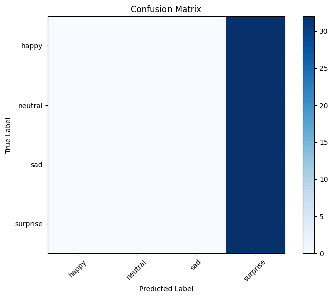

```python
import numpy as np
import matplotlib.pyplot as plt
from sklearn.metrics import confusion_matrix
from tensorflow.keras.utils import to_categorical

# Convert labels to categorical
y_true = to_categorical(test_generator_grayscale.classes)

# Predict probabilities for the test set
y_pred_probs = model_complex.predict(test_generator_grayscale)

# Get predicted labels
y_pred = np.argmax(y_pred_probs, axis=1)

# Get class labels
class_labels = list(test_generator_grayscale.class_indices.keys())

# Calculate confusion matrix
conf_matrix = confusion_matrix(np.argmax(y_true, axis=1), y_pred)

# Plot confusion matrix
plt.figure(figsize=(8, 6))
plt.imshow(conf_matrix, cmap=plt.cm.Blues)
plt.title('Confusion Matrix')
plt.colorbar()
plt.xticks(np.arange(len(class_labels)), class_labels, rotation=45)
plt.yticks(np.arange(len(class_labels)), class_labels)
plt.xlabel('Predicted Label')
plt.ylabel('True Label')
plt.tight_layout()

# Show plot
plt.show()
```

**Observations and Insights:__**

## **Conclusion:*__***

### **Refined insights**:

- What are the most meaningful insights from the data relevant to the problem?

### **Comparison of various techniques and their relative performance**:

- How do different techniques perform? Which one is performing relatively better? Is there scope to improve the performance further?

### **Proposal for the final solution design**:

- What model do you propose to be adopted? Why is this the best solution to adopt?

Observations and Insights:

Transfer Learning Models:

Both the ResNet V2-based model and the EfficientNet-based model exhibited relatively low performance compared to expectations. The ResNet V2 model achieved a test accuracy of around 68.75%, while the EfficientNet model achieved only 25% accuracy. These accuracies are lower than desirable and suggest that the pre-trained models might not be well-suited for the given task or dataset. Complex Convolutional Neural Network:

Performance Comparison:

Exploration of Custom Architectures:

Given the limitations of pre-trained models and the complex CNN architecture, it may be beneficial to explore custom CNN architectures tailored specifically for the task of facial emotion recognition. These architectures can be designed to capture relevant features and patterns present in facial images, potentially leading to improved performance. Data Augmentation and Preprocessing:

Data augmentation techniques, such as rotation, scaling, and flipping, can be applied to increase the diversity of training data and improve model generalization. Preprocessing steps, including normalization and noise reduction, can help enhance the quality of input images and facilitate better feature extraction. Hyperparameter Tuning and Optimization:

Hyperparameter tuning, including learning rate optimization, regularization techniques, and batch size adjustments, can help fine-tune the model for improved performance. Regularization techniques, such as dropout and batch normalization, can prevent overfitting and improve model generalization. Ensemble Learning:

Ensemble learning techniques, such as model averaging or stacking, can be employed to combine predictions from multiple models and improve overall performance. By leveraging diverse models or variations of the same model, ensemble methods can capture complementary information and enhance predictive accuracy. In summary, the proposed solution involves exploring custom CNN architectures, augmenting and preprocessing data, optimizing model hyperparameters, and potentially employing ensemble learning techniques to address the challenges in facial emotion recognition effectively. Through iterative experimentation and refinement, we aim to develop a robust and accurate model tailored to the specific requirements of the task.